# Practical Machine Learning Project

Sarim

20/06/2020

# Introduction

Using devices such as Jawbone Up, Nike FuelBand, and Fitbit it is now possible to collect a large amount of data about personal activity relatively inexpensively. In this project, our goal will be to use data from accelerometers on the belt, forearm, arm, and dumbell of 6 participants.

The training data for this project are available here:

https://d396qusza40orc.cloudfront.net/predmachlearn/pml-training.csv

The test data are available here:

https://d396qusza40orc.cloudfront.net/predmachlearn/pml-testing.csv

The data for this project come from this source: http://groupware.les.inf.puc-rio.br/har.

We will be using decision trees and random forest methods for predictions

# Data Processing

## Libraries Used

```r
library(caret)
```

```r
library(rpart)
library(rpart.plot)
library(rattle)
library(randomForest)
```

## Loading Data

```r
#Before doing any operations we set the seed to maintain reproducibility
set.seed(12345)
training<-read.csv("pml-training.csv",na.strings=c("NA","#DIV/0!", ""))
testing<-read.csv("pml-testing.csv",na.strings=c("NA","#DIV/0!", ""))
```

## Cleaning Data

The datasets loaded have a few columns which have no results and the first 7 columns have no information which will help us in the predictions. So we remove these columns for both the datasets. Also the predicted variable *classe* is a factor but present as a character and so it is converted into a factor variable.

```r
training<-training[,colSums(is.na(training))==0]
testing<-testing[,colSums(is.na(testing))==0]
training<-training[,-c(1:7)]
testing<-testing[,-c(1:7)]

# Converting classe to factor type
training$classe<-as.factor(training$classe)
```

## Partitioning of data

The testing set is kept aside for final test just once and the training set is divided into two subsets - for training and cross validation. The two datasets are created using *createDataPartition* with a prob distribution of 60% and 40% in favour of training.

```r
inTrain<-createDataPartition(training$classe,p=0.6,list=FALSE)
newTraining<-training[inTrain,]
newTesting<-training[-inTrain,]
```

# Prediction

Before diving into the prediction we first look the variable we are dealing with and do some simple analysis

```r
summary(newTraining$classe)
```

```
##    A    B    C    D    E
## 3348 2279 2054 1930 2165
```

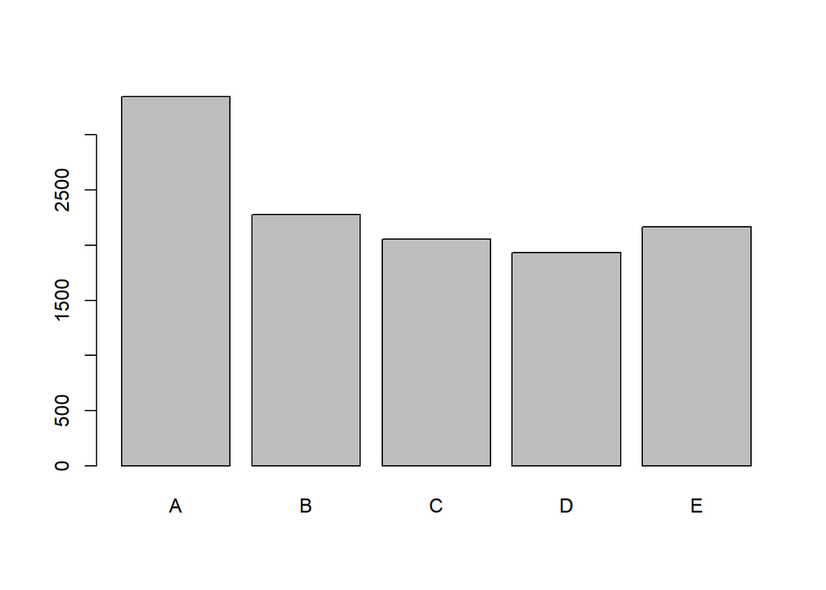

```r
plot(newTraining$classe)
```

From the plot we can see that *classe* is factor with 5 levels *A,B,C,D and E*. *A* level is significantly more while all others are close to each other.

## Decision Trees using rpart

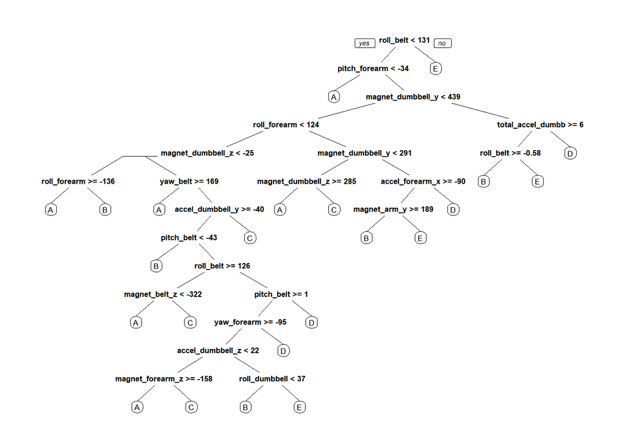

```r
fit1<-rpart(classe ~ ., data=newTraining, method="class")
prp(fit1)
```

```r
pred1<-predict(fit1,newTesting,type = "class")
confusionMatrix(pred1,newTesting$classe)
```

```
## Confusion Matrix and Statistics
##
##           Reference
## Prediction    A    B    C    D    E
##          A 1995  246   49   83   51
##          B   75  890  111  119  115
##          C   44  198 1094  153  143
##          D   74  112   79  840   94
##          E   44   72   35   91 1039
##
## Overall Statistics
##
##                Accuracy : 0.7466
##                  95% CI : (0.7368, 0.7562)
##     No Information Rate : 0.2845
##     P-Value [Acc > NIR] : < 2.2e-16
##
##                   Kappa : 0.6787
##
##  Mcnemar's Test P-Value : < 2.2e-16
##
## Statistics by Class:
##
##                      Class: A Class: B Class: C Class: D Class: E
## Sensitivity            0.8938   0.5863   0.7997   0.6532   0.7205
## Specificity            0.9236   0.9336   0.9169   0.9453   0.9622
## Pos Pred Value         0.8230   0.6794   0.6703   0.7006   0.8111
## Neg Pred Value         0.9563   0.9039   0.9559   0.9329   0.9386
## Prevalence             0.2845   0.1935   0.1744   0.1639   0.1838
## Detection Rate         0.2543   0.1134   0.1394   0.1071   0.1324
## Detection Prevalence   0.3089   0.1670   0.2080   0.1528   0.1633
## Balanced Accuracy      0.9087   0.7600   0.8583   0.7992   0.8414
```

As can be seen by the result of the confusion matrix this is not a very good predictor and gives an accuracy of about 75%.This model does not have good sensitivity but has decent specificity. So we look for a better method if possible.

## Random Forest

```r
fit2<-randomForest(classe ~.,newTraining)
pred2<-predict(fit2,newTesting,type = "class")
confusionMatrix(pred2,newTesting$classe)
```

```
## Confusion Matrix and Statistics
##
##           Reference
## Prediction    A    B    C    D    E
##          A 2229    3    0    0    0
##          B    3 1515    6    0    0
##          C    0    0 1357    6    2
##          D    0    0    5 1280    5
##          E    0    0    0    0 1435
##
## Overall Statistics
##
##                Accuracy : 0.9962
##                  95% CI : (0.9945, 0.9974)
##     No Information Rate : 0.2845
##     P-Value [Acc > NIR] : < 2.2e-16
##
##                   Kappa : 0.9952
##
##  Mcnemar's Test P-Value : NA
##
## Statistics by Class:
##
##                      Class: A Class: B Class: C Class: D Class: E
## Sensitivity            0.9987   0.9980   0.9920   0.9953   0.9951
## Specificity            0.9995   0.9986   0.9988   0.9985   1.0000
## Pos Pred Value         0.9987   0.9941   0.9941   0.9922   1.0000
## Neg Pred Value         0.9995   0.9995   0.9983   0.9991   0.9989
## Prevalence             0.2845   0.1935   0.1744   0.1639   0.1838
## Detection Rate         0.2841   0.1931   0.1730   0.1631   0.1829
## Detection Prevalence   0.2845   0.1942   0.1740   0.1644   0.1829
## Balanced Accuracy      0.9991   0.9983   0.9954   0.9969   0.9976
```

The random forest method provides great result with accuracy over 99%. This method is great for our data and no further improvement looks likely and so this method can be used for any further predictions related to this type of data.

```r
pred_test<-predict(fit2,testing,type = "class")
```